# Alpha diveristy across different ecosystems

Alpha diveristy across different ecosystems Xin (David) Zhao Last edited 20 February 2023

## 0.1 Problem

## 0.2 Solution

## 0.3 Project outline

1. Estimate five alpha diversities across major body sites
2. Compare alpha diversities by body sites + visualization + interpretation
3. Correlation between various alpha diversities + visualization + interpretation
4. Multivariate regression on alpha diversities and environmental variables + visualization + interpretation

## 0.4 R codes

### 0.4.1 Load necessary libraries

```r
# load library necessary for this project
# install.package("ggstatsplot", dependencies = TRUE)
library(ggstatsplot)  # forest plot for model output

library(tidyverse)
library(vegan)
library(phyloseq) # import and process qimme output files
library(phyloseqCompanion)
library(ggpubr)
library(picante)  # estimate Faith's PD
library(Hmisc)  # calculate correlation values and p
library(corrplot) # draw correlation matrix
library(PerformanceAnalytics)
library(zCompositions) # treat missing and zero values
library(caret)  # machine learning package including checking highly correlation variables
library(lares)  # compute and plot correlations
library(parameters)  # tabulate model summary
library(gt) # get a compact and comprehensive summary table in HTML file
```

### 0.4.2 Import metagenomic 16S sequence data and metadata

Human microbiome project (HMP) 16S rRNA gene diversity: examines the diversity of 16S RNA genes in the human microbiome for the human microbiome project (HMP)(“A Framework for Human Microbiome Research” 2012)

- Cohort: Center “Healthy Cohort”
- Data type: 16S metagenomic sequence - NCBI Bioproject ID: 48489
- 300 human subjects, up to 3 time points, 5 body sites
- Metadata: Unique subject ID, body site, sex and visit number which are accessible via [the HMP metadata catalog](https://hmpdacc.org/hmp/catalog/grid.php?dataset=metagenomic)

Download Qiime-processed OTU table (v3-5) and phylogenetic trees (v3-5) from the [website](https://hmpdacc.org/hmp/HMQCP/#data).

```r
# extract OTU table data from .gz files

otu_v35_hmp <- read.delim(gzfile("C:/Users/17803/Documents/RStuodio-link-GitHub/alpha-diversity-ecosystems/otu_table_v35.txt.gz"),
                      header = FALSE)  # whether the first line describe the column names

head(otu_v35_hmp)
```

|  | V1 | V2 | V3 | V4 | V5 | V6 | V7 | V8 | V9 | V10 | V11 | V12 | V13 | V14 | V15 | V16 | V17 | V18 | V19 | V20 | V21 | V22 | V23 | V24 | V25 | V26 | V27 | V28 | V29 | … |
| --- | --- | --- | --- | --- | --- | --- | --- | --- | --- | --- | --- | --- | --- | --- | --- | --- | --- | --- | --- | --- | --- | --- | --- | --- | --- | --- | --- | --- | --- | --- |
| 1 | # QIIME v1.3.0-dev OTU table |  |  |  |  |  |  |  |  |  |  |  |  |  |  |  |  |  |  |  |  |  |  |  |  |  |  |  |  | … |
| 2 | #OTU ID | 700014390.V35.241827 | 700014391.V35.241827 | 700014405.V35.241827 | 700014406.V35.241827 | 700014410.V35.241827 | 700014411.V35.241827 | 700014413.V35.241827 | 700014414.V35.241827 | 700014416.V35.241827 | 700014417.V35.241827 | 700014419.V35.241827 | 700014420.V35.241827 | 700014423.V35.241827 | 700014425.V35.241827 | 700014426.V35.241827 | 700014428.V35.241827 | 700014429.V35.241827 | 700014431.V35.241827 | 700014432.V35.241827 | 700014443.V35.241827 | 700014446.V35.241827 | 700014489.V35.241766 | 700014490.V35.241766 | 700014503.V35.241762 | 700014504.V35.241762 | 700014511.V35.241762 | 700014512.V35.241762 | 700014528.V35.241762 | … |
| 3 | OTU_97.1 | 0 | 0 | 0 | 0 | 0 | 0 | 0 | 0 | 0 | 0 | 0 | 0 | 0 | 0 | 0 | 0 | 0 | 0 | 0 | 0 | 0 | 0 | 0 | 0 | 0 | 0 | 0 | 0 | … |
| 4 | OTU_97.10 | 0 | 0 | 0 | 0 | 0 | 0 | 0 | 0 | 0 | 0 | 0 | 0 | 0 | 0 | 0 | 0 | 0 | 0 | 0 | 0 | 0 | 0 | 0 | 0 | 0 | 0 | 0 | 4 | … |
| 5 | OTU_97.100 | 0 | 0 | 0 | 0 | 0 | 0 | 0 | 0 | 0 | 0 | 0 | 0 | 0 | 0 | 0 | 0 | 0 | 0 | 0 | 0 | 0 | 0 | 0 | 480 | 181 | 0 | 0 | 0 | … |
| 6 | OTU_97.1000 | 0 | 0 | 0 | 0 | 0 | 0 | 0 | 0 | 0 | 0 | 0 | 0 | 0 | 0 | 0 | 0 | 0 | 0 | 0 | 0 | 0 | 0 | 0 | 0 | 0 | 0 | 0 | 0 | … |

```r
# unzip the final OTU table after removing mislabeling and contamination
otu_v35_final_hmp <- read.delim(gzfile("./otu_table_psn_v35.txt.gz"),
                                header = FALSE)  # whether the first line describe the column names
```

Read in the Qiime-output phylogenetic tree object using `phyloseq` R package. Follow the instruction in the section, `4.5 Import from QIIME Legacy` in the [vignette](https://www.bioconductor.org/packages/release/bioc/vignettes/phyloseq/inst/doc/phyloseq-basics.html#load-phyloseq).

```r
# view the instruction of phyloseq package
# vignette("phyloseq_analysis")


# otu table file
otu_hmp_phylo <- gzfile("./otu_table_psn_v35.txt.gz")

# phylogenetic tree file
ph.tree_hmp_phylo <- gzfile("./rep_set_v35.tre.gz")


# import both files with phyloseq package
hmp_phyloseq <- import_qiime(otufilename = otu_hmp_phylo,
                             treefilename = ph.tree_hmp_phylo)
```

```
## Processing otu/tax file...
## Reading file into memory prior to parsing...
## Detecting first header line...
## Header is on line 2
## Converting input file to a table...
## Defining OTU table...
## Parsing taxonomy table...
## Processing phylogenetic tree...
##  5 ...
```

```r
hmp_phyloseq  # phylogenetic object
```

```
## phyloseq-class experiment-level object
## otu_table()   OTU Table:         [ 45336 taxa and 4788 samples ]
## tax_table()   Taxonomy Table:    [ 45336 taxa by 6 taxonomic ranks ]
## phy_tree()    Phylogenetic Tree: [ 45336 tips and 45099 internal nodes ]
```

Now the resulting phyloseq-class object contains an `OTU-table`, `taxomony table` and `phylogenetic tree`.

Mapping file (16S variable region v35) was accessible from this [website](https://hmpdacc.org/hmp/resources/metagenomics_sequencing_analysis.php).

Convert the imported mapping file to phyloseq class `sample data` using `import_qiime_sample_data()` function of phyloseq package.

```r
sample_data_phylo <- import_qiime_sample_data("./v35_map_uniquebyPSN.txt.bz2")   # import Qiime-output sample data
```

```r
table(sample_data_phylo$HMPbodysubsite)   # check the distribution of sub-body sites
```

```
##
##               Anterior_nares Attached_Keratinized_gingiva
##                          282                          313
##                Buccal_mucosa                  Hard_palate
##                          312                          308
##       Left_Antecubital_fossa   Left_Retroauricular_crease
##                          225                          300
##                   Mid_vagina             Palatine_Tonsils
##                          134                          315
##             Posterior_fornix      Right_Antecubital_fossa
##                          133                          241
##  Right_Retroauricular_crease                       Saliva
##                          305                          292
##                        Stool           Subgingival_plaque
##                          321                          309
##         Supragingival_plaque                       Throat
##                          314                          310
##                Tongue_dorsum            Vaginal_introitus
##                          316                          127
```

Next, merge the sample data and previous phyloseq object into a self-consistent, phyloseq-class object, using `merge_phyloseq`. The resulting phyloseq object contains an OTU table, sample-data, and pylogenetic tree.

```r
hmp_phylo_data <- merge_phyloseq(sample_data_phylo, hmp_phyloseq)  # merge sample data and previous phyloseq-class object
```

Calculate alpha diversity by following the [vignettes](https://www.bioconductor.org/packages/release/bioc/vignettes/phyloseq/inst/doc/phyloseq-analysis.html#simple-exploratory-graphics)

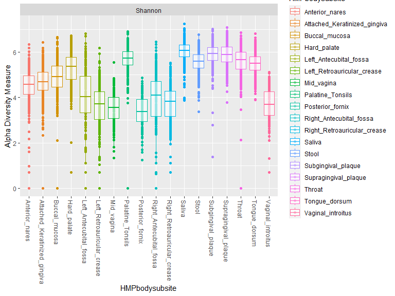

```r
# remove OTU not present in any samples
hmp_filter <- prune_taxa(taxa_sums(hmp_phylo_data) >0, hmp_phylo_data)

# alpha diversity metrics of interest
alpha_metrics <- c("Observed", "Chao1", "ACE", "Shannon", "Simpson", "InvSimpson")

# plot based on alpha-diversity of stool samples alone

plot_richness(hmp_filter,  # phyloseq object
              x = "HMPbodysubsite",  # a variable to map to the x-axis
              color = "HMPbodysubsite",
              measures = "Shannon")  + # calculate shannon
        geom_boxplot(alpha = 0.6)
```

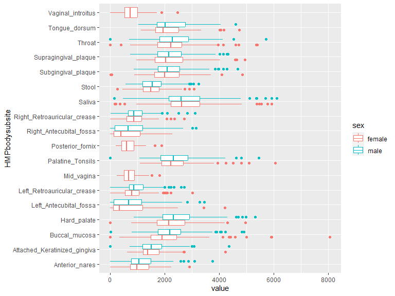

```r
alpha_plot <- plot_richness(hmp_filter,  # phyloseq object
                            x = "sex",  # a variable to map to the x-axis
                            color = "HMPbodysubsite",
                            measures = "Chao1") # calculate chao1


# plot with ggplot2
ggplot(data = alpha_plot$data,
       aes(x= HMPbodysubsite, y=value, color = sex),
       alpha = 0,1) +
        geom_boxplot() +
        coord_flip()
```

### 0.4.3 Estimate alpha diversity metrics using estimate_richness function

The function, `estimate_richness` in the `phyloseq` package returns several commonly used alpha-diversity metrics:

- Observed
- Chao1
- ACE
- Shannon
- Simpson
- InvSimpson

Next, calculate alpha-diversity metrics across different sub-body sites, referring to this [instruction](https://rpubs.com/lconteville/713954)

```r
# 18 sub-body sites
table(sample_data(hmp_filter)$HMPbodysubsite)
```

```
##
##               Anterior_nares Attached_Keratinized_gingiva
##                          269                          313
##                Buccal_mucosa                  Hard_palate
##                          312                          302
##       Left_Antecubital_fossa   Left_Retroauricular_crease
##                          201                          285
##                   Mid_vagina             Palatine_Tonsils
##                          133                          312
##             Posterior_fornix      Right_Antecubital_fossa
##                          133                          207
##  Right_Retroauricular_crease                       Saliva
##                          297                          290
##                        Stool           Subgingival_plaque
##                          319                          309
##         Supragingival_plaque                       Throat
##                          313                          307
##                Tongue_dorsum            Vaginal_introitus
##                          316                          125
```

Referring to the below map sourced from the human microbiome project, I assigned sub-body sites to five (major) body sites.

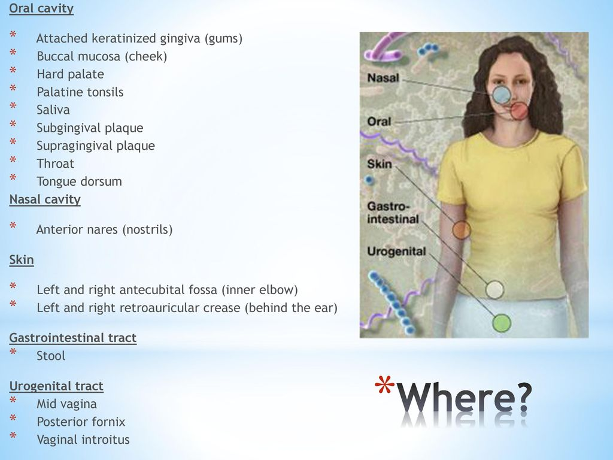

Where are body sites

```r
# add body_site to the sample data
# convert sample data to data frame for following manipulation
sample_data2 <- phyloseqCompanion::sample.data.frame(hmp_filter)

class(sample_data2) # check if data frame
```

```
## [1] "data.frame"
```

```r
sample_data2 <- sample_data2 %>%
  mutate(body_site = case_when(
    HMPbodysubsite %in% c("Attached_Keratinized_gingiva",
                          "Buccal_mucosa",
                          "Hard_palate",
                          "Palatine_Tonsils",
                          "Saliva",
                          "Subgingival_plaque",
                          "Supragingival_plaque",
                          "Throat",
                          "Tongue_dorsum") ~ "oral_cavity",
    HMPbodysubsite %in% c(
      "Anterior_nares"
    )~ "nasal_cavtiy",
    HMPbodysubsite %in% c(
      "Left_Antecubital_fossa",
      "Right_Antecubital_fossa",
      "Left_Retroauricular_crease",
      "Right_Retroauricular_crease"
    )~ "skin",
    HMPbodysubsite %in% c(
      "Stool"
    ) ~ "gastrointestinal_tract",
    HMPbodysubsite %in% c(
      "Mid_vagina",
      "Posterior_fornix",
      "Vaginal_introitus"
    ) ~ "urogenital_tract")
    )

# check the new column
table(sample_data2$body_site)
```

```
##
## gastrointestinal_tract           nasal_cavtiy            oral_cavity
##                    319                    269                   2774
##                   skin       urogenital_tract
##                    990                    391
```

```r
# integrate the updated sample data into the phyloseq object

sample_data3 <- sample_data(sample_data2)

hmp_filter2 <- merge_phyloseq(sample_data3, hmp_phyloseq)
```

Estimate alpha-diversity measures by body sites

```r
alpha_div_hmp <- phyloseq::estimate_richness(hmp_filter2,
                                             split = TRUE,
                                             measures = c("Observed", # remove Fisher since vegan implementation dose not work anymore
                                                          "Chao1",
                                                          "ACE",
                                                          "Shannon",
                                                          "Simpson",
                                                          "InvSimpson"))

head(alpha_div_hmp) # view first rows
```

|  | Observed | Chao1 | se.chao1 | ACE | se.ACE | Shannon | Simpson | InvSimpson |
| --- | --- | --- | --- | --- | --- | --- | --- | --- |
| X700114607 | 2 | 3.000 | 2.041241 | NaN | NaN | 0.6931472 | 0.5000000 | 2.00000 |
| X700114424 | 15 | 70.000 | 34.863458 | 37.94803 | 2.537692 | 2.5350252 | 0.9062500 | 10.66667 |
| X700114712 | 1308 | 3072.282 | 180.731632 | 3339.03574 | 40.117100 | 5.6003867 | 0.9791189 | 47.89016 |
| X700114713 | 1341 | 2763.057 | 146.081739 | 2840.41940 | 34.269756 | 6.0508867 | 0.9913725 | 115.90813 |
| X700114554 | 711 | 1411.991 | 101.971941 | 1432.46062 | 23.797045 | 4.9824609 | 0.9790836 | 47.80928 |
| X700114606 | 1416 | 2527.729 | 114.071472 | 2574.37189 | 30.976875 | 6.4212842 | 0.9960446 | 252.82161 |

Next, compare various alpha-diversity metrics across five body sites - Are alpha diversity different among body sites?

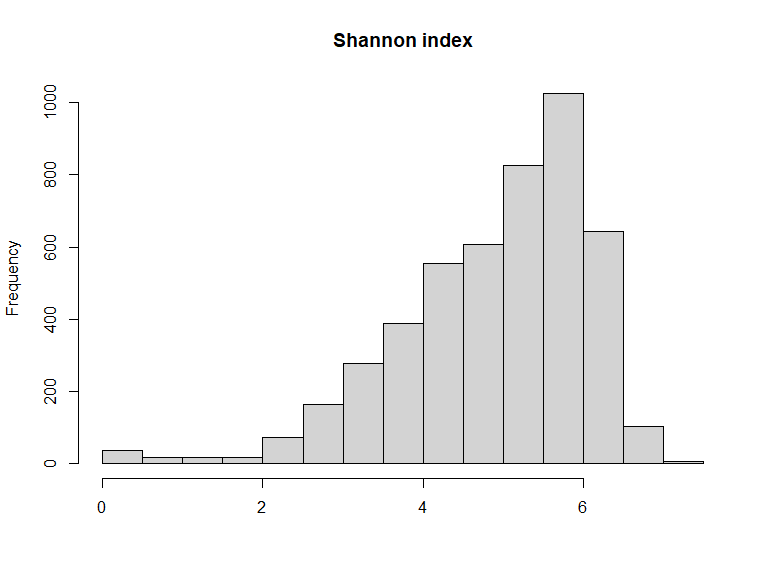

```r
# check if normal distribution for Shannon

hist(alpha_div_hmp$Shannon, main = "Shannon index", xlab = "")
```

```r
anova.sh <- aov(alpha_div_hmp$Shannon ~ sample_data(hmp_filter2)$body_site)
summary(anova.sh)
```

```
##                                      Df Sum Sq Mean Sq F value Pr(>F)
## sample_data(hmp_filter2)$body_site    4   3145   786.3    1070 <2e-16 ***
## Residuals                          4738   3483     0.7
## ---
## Signif. codes:  0 '***' 0.001 '**' 0.01 '*' 0.05 '.' 0.1 ' ' 1
```

Run a post hoc test, Tukey honest significance difference (Tukey’s HSD) after the ANOVA test.

```r
TukeyHSD(anova.sh)
```

```
##   Tukey multiple comparisons of means
##     95% family-wise confidence level
##
## Fit: aov(formula = alpha_div_hmp$Shannon ~ sample_data(hmp_filter2)$body_site)
##
## $`sample_data(hmp_filter2)$body_site`
##                                                diff        lwr         upr
## nasal_cavtiy-gastrointestinal_tract     -1.10354336 -1.2972121 -0.90987466
## oral_cavity-gastrointestinal_tract      -0.08482912 -0.2231487  0.05349046
## skin-gastrointestinal_tract             -1.80789584 -1.9585216 -1.65727012
## urogenital_tract-gastrointestinal_tract -2.02750251 -2.2040200 -1.85098503
## oral_cavity-nasal_cavtiy                 1.01871425  0.8693097  1.16811882
## skin-nasal_cavtiy                       -0.70435248 -0.8652174 -0.54348754
## urogenital_tract-nasal_cavtiy           -0.92395914 -1.1092908 -0.73862744
## skin-oral_cavity                        -1.72306673 -1.8096824 -1.63645110
## urogenital_tract-oral_cavity            -1.94267339 -2.0690561 -1.81629073
## urogenital_tract-skin                   -0.21960667 -0.3593507 -0.07986268
##                                             p adj
## nasal_cavtiy-gastrointestinal_tract     0.0000000
## oral_cavity-gastrointestinal_tract      0.4505144
## skin-gastrointestinal_tract             0.0000000
## urogenital_tract-gastrointestinal_tract 0.0000000
## oral_cavity-nasal_cavtiy                0.0000000
## skin-nasal_cavtiy                       0.0000000
## urogenital_tract-nasal_cavtiy           0.0000000
## skin-oral_cavity                        0.0000000
## urogenital_tract-oral_cavity            0.0000000
## urogenital_tract-skin                   0.0001784
```

Alternatively, run Kruskal-Wallis rank sum test on non-normal distributed dataset.

```r
kruskal.test(alpha_div_hmp$Shannon ~ sample_data(hmp_filter2)$body_site)
```

```
##
##  Kruskal-Wallis rank sum test
##
## data:  alpha_div_hmp$Shannon by sample_data(hmp_filter2)$body_site
## Kruskal-Wallis chi-squared = 2304.7, df = 4, p-value < 2.2e-16
```

Get p-values of the Wilcoxon tests comparing each pair of groups.

```r
pairwise.wilcox.test(alpha_div_hmp$Shannon, sample_data(hmp_filter2)$body_site,
                     p.adj = "bonf")  # multiple comparison adjustment - bonferroni
```

```
##
##  Pairwise comparisons using Wilcoxon rank sum test with continuity correction
##
## data:  alpha_div_hmp$Shannon and sample_data(hmp_filter2)$body_site
##
##                  gastrointestinal_tract nasal_cavtiy oral_cavity skin
## nasal_cavtiy     <2e-16                 -            -           -
## oral_cavity      1                      <2e-16       -           -
## skin             <2e-16                 <2e-16       <2e-16      -
## urogenital_tract <2e-16                 <2e-16       <2e-16      5e-07
##
## P value adjustment method: bonferroni
```

### 0.4.4 Estimate Faith’s PD using picante R package

The package `picante` can estimate the phylogenetic aware metric, Faith’s PD, which `phyloseq` package cannot do.

Apply `pd` function to OTU table and phylogenetic tree, following the [instruction](https://rdrr.io/rforge/picante/man/pd.html). The function `pd` returns a data frame of the `PD` and species (`SR`) values for all samples.

```r
# faith_pd <- picante::pd(samp = t(otu_table(hmp_filter2)),
#                         tree = phy_tree(hmp_filter2),
#                         include.root = F)  # tree need not rooted, but in case of single-species samples the PD will be equal to NA

# head(faith_pd)

# As picante::pd() takes a long, long time to run, I export faith_pd as an external file for generating html.


# write.csv(faith_pd,
#           file = "faith_pd_HMP.csv")

faith_pd <- read.csv("faith_pd_HMP.csv", header = T,
                     col.names = c("SampleID", "PD", "SR"))
```

### 0.4.5 Tabulate descriptive statsitics of five alpha diversity metrics

```r
str(faith_pd)  # PD data frame
```

```
## 'data.frame':    4743 obs. of  3 variables:
##  $ SampleID: int  700114607 700114424 700114712 700114713 700114554 700114606 700114335 700114707 700114442 700114610 ...
##  $ PD      : num  0 0.885 32.053 36.855 22.04 ...
##  $ SR      : int  2 15 1308 1341 711 1416 1356 1220 905 490 ...
```

```r
str(alpha_div_hmp)  # other alpha diversities
```

```
## 'data.frame':    4743 obs. of  8 variables:
##  $ Observed  : num  2 15 1308 1341 711 ...
##  $ Chao1     : num  3 70 3072 2763 1412 ...
##  $ se.chao1  : num  2.04 34.86 180.73 146.08 101.97 ...
##  $ ACE       : num  NaN 37.9 3339 2840.4 1432.5 ...
##  $ se.ACE    : num  NaN 2.54 40.12 34.27 23.8 ...
##  $ Shannon   : num  0.693 2.535 5.6 6.051 4.982 ...
##  $ Simpson   : num  0.5 0.906 0.979 0.991 0.979 ...
##  $ InvSimpson: num  2 10.7 47.9 115.9 47.8 ...
```

```r
str(sample_data2)  # metadata
```

```
## 'data.frame':    4743 obs. of  10 variables:
##  $ X.SampleID    : int  700114607 700114424 700114712 700114713 700114554 700114606 700114335 700114707 700114442 700114610 ...
##  $ RSID          : int  763901136 764042746 764831721 764831721 875002022 763901136 765560005 764831721 764042746 763901136 ...
##  $ visitno       : int  2 2 2 2 1 2 2 2 2 2 ...
##  $ sex           : chr  "female" "female" "male" "male" ...
##  $ RUNCENTER     : chr  "WUGC" "WUGC" "WUGC" "WUGC" ...
##  $ HMPbodysubsite: chr  "Left_Retroauricular_crease" "Left_Retroauricular_crease" "Attached_Keratinized_gingiva" "Palatine_Tonsils" ...
##  $ Mislabeled    : logi  FALSE FALSE FALSE FALSE FALSE FALSE ...
##  $ Contaminated  : logi  FALSE FALSE FALSE FALSE FALSE FALSE ...
##  $ Description   : chr  "HMP_Human_metagenome_sample_700114607_from_subject_763901136__sex_female_" "HMP_Human_metagenome_sample_700114424_from_subject_764042746__sex_female_" "HMP_Human_metagenome_sample_700114712_from_subject_764831721__sex_male_" "HMP_Human_metagenome_sample_700114713_from_sub…
##  $ body_site     : chr  "skin" "skin" "oral_cavity" "oral_cavity" ...
```

```r
# prepare faith's PD table
faith_pd_sub <- faith_pd %>%
  # rownames_to_column("SampleID") %>%
  dplyr::select(-SR)

faith_pd_sub$SampleID <- as.character(faith_pd_sub$SampleID)


# prepare pyloseq-output alpha diversities
alpha_div_hmp_sub <- alpha_div_hmp %>%
  rownames_to_column("SampleID") %>%
  dplyr::mutate(SampleID2 = str_sub(SampleID, 2)) %>%
  dplyr::select(-SampleID) %>%
  rename(SampleID = SampleID2) %>%
  dplyr::select(SampleID, Chao1, se.chao1, Shannon, Simpson, InvSimpson)


# prepare metadata
sample_data_sub <- sample_data2 %>%
  dplyr::select(SampleID = X.SampleID, body_site)

sample_data_sub$SampleID <- as.character(sample_data_sub$SampleID)  # convert to character variable


# merge three the above tables by Sample ID using full merge

merg_alpha <- sample_data_sub %>%
  dplyr::full_join(alpha_div_hmp_sub, by= "SampleID") %>%
  dplyr::full_join(faith_pd_sub, by= "SampleID")

head(merg_alpha) # view first rows
```

|  | SampleID | body_site | Chao1 | se.chao1 | Shannon | Simpson | InvSimpson | PD |
| --- | --- | --- | --- | --- | --- | --- | --- | --- |
| 1 | 700114607 | skin | 3.000 | 2.041241 | 0.6931472 | 0.5000000 | 2.00000 | 0.00000 |
| 2 | 700114424 | skin | 70.000 | 34.863458 | 2.5350252 | 0.9062500 | 10.66667 | 0.88531 |
| 3 | 700114712 | oral_cavity | 3072.282 | 180.731632 | 5.6003867 | 0.9791189 | 47.89016 | 32.05334 |
| 4 | 700114713 | oral_cavity | 2763.057 | 146.081739 | 6.0508867 | 0.9913725 | 115.90813 | 36.85539 |
| 5 | 700114554 | nasal_cavtiy | 1411.991 | 101.971941 | 4.9824609 | 0.9790836 | 47.80928 | 22.03953 |
| 6 | 700114606 | oral_cavity | 2527.729 | 114.071472 | 6.4212842 | 0.9960446 | 252.82161 | 47.73164 |

Calculate summary statistics for five alpha diversities with body site groups

```r
summ_alpha <- merg_alpha %>%
  group_by(body_site) %>%
  dplyr::summarize(chao_ave = mean(Chao1),  # average for Chao1
                   chao_std = sd(Chao1), # standard deviations for Chao1
                   shannon_ave = mean(Shannon),  # Shannon average
                   shannon_std = sd(Shannon),  # Shannon std
                   simpson_ave = mean(Simpson),  # Simpson average
                   simpson_std = sd(Simpson),  # Simpson std
                   invsimp_ave = mean(InvSimpson),  # InvSimpson average
                   invsimp_std = sd(InvSimpson), # InvSimpson std
                   pd_ave = mean(PD),  # PD average
                   pd_std = sd(PD),  # PD std
                   sub_size = n())  # group sizes

summ_alpha_dig <- summ_alpha

summ_alpha_dig[,-1] <- apply(summ_alpha_dig[,-1], 2, function(x) round(x, 2))  # two decimal digits

summ_alpha_dig # print the resulting table
```

| body_site | chao_ave | chao_std | shannon_ave | shannon_std | simpson_ave | simpson_std | invsimp_ave | invsimp_std | pd_ave | pd_std | sub_size |
| --- | --- | --- | --- | --- | --- | --- | --- | --- | --- | --- | --- |
| gastrointestinal_tract | 1572.32 | 539.27 | 5.55 | 0.49 | 0.99 | 0.01 | 108.00 | 65.17 | 29.46 | 10.83 | 319 |
| nasal_cavtiy | 1095.70 | 565.39 | 4.45 | 0.91 | 0.94 | 0.13 | 37.20 | 31.98 | NA | NA | 269 |
| oral_cavity | 2233.53 | 836.65 | 5.47 | 0.77 | 0.97 | 0.06 | 93.29 | 80.57 | NA | NA | 2774 |
| skin | 843.90 | 618.60 | 3.74 | 1.17 | 0.88 | 0.17 | 23.71 | 31.34 | NA | NA | 990 |
| urogenital_tract | 714.15 | 329.03 | 3.52 | 0.73 | 0.87 | 0.10 | 13.89 | 11.62 | 14.89 | 5.97 | 391 |

Draw bar plots with error bars to illustrate the summary stats.

Refer to the instruction [here](https://stringr.tidyverse.org/reference/str_extract.html) to set regular expression for `str_extract` function.

```r
# prepare data
summ_alpha_dig2 <- summ_alpha_dig %>%
  tidyr::gather(key = "alpha_metrics",
                value = "value",
                -c("body_site",
                   "sub_size")) %>%
  dplyr::mutate(stats_metrics = str_sub(alpha_metrics, -3)) %>%
  dplyr::mutate(alpha_metric = str_extract(alpha_metrics, "[a-z]+"))  %>%
  dplyr::select(-alpha_metrics) %>%
  tidyr::spread(key = "stats_metrics", value = "value")


summ_alpha_dig2  # print the table
```

| body_site | sub_size | alpha_metric | ave | std |
| --- | --- | --- | --- | --- |
| gastrointestinal_tract | 319 | chao | 1572.32 | 539.27 |
| gastrointestinal_tract | 319 | invsimp | 108.00 | 65.17 |
| gastrointestinal_tract | 319 | pd | 29.46 | 10.83 |
| gastrointestinal_tract | 319 | shannon | 5.55 | 0.49 |
| gastrointestinal_tract | 319 | simpson | 0.99 | 0.01 |
| nasal_cavtiy | 269 | chao | 1095.70 | 565.39 |
| nasal_cavtiy | 269 | invsimp | 37.20 | 31.98 |
| nasal_cavtiy | 269 | pd | NA | NA |
| nasal_cavtiy | 269 | shannon | 4.45 | 0.91 |
| nasal_cavtiy | 269 | simpson | 0.94 | 0.13 |

[output cut: 15 more lines]

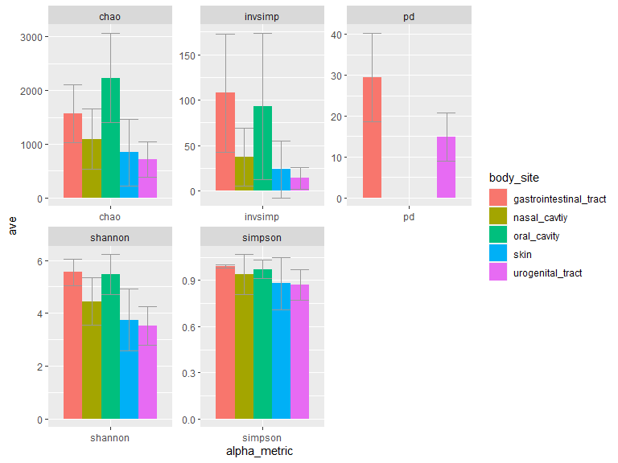

```r
summ_alpha_dig3 <- summ_alpha_dig2 %>%
  mutate(Ymax = ave + std) %>%
  mutate(Ymin = ave - std)

ggplot(summ_alpha_dig3,
       aes(x = alpha_metric, y = ave, fill = body_site)) +
  geom_col(position = "dodge") +
  geom_errorbar(data = summ_alpha_dig3,
                position = "dodge",
                aes(ymax= Ymax,
                ymin = Ymin),
                na.rm = T,
                size = 0.1,
                linetype =1,
                color = "gray60") +
  facet_wrap(vars(alpha_metric),
             scales = "free")
```

### 0.4.6 Correlaion matrix between five alpha diveristies

Use `rcorr` function in `Hmisc` package following the instruction [here](http://www.sthda.com/english/wiki/correlation-matrix-a-quick-start-guide-to-analyze-format-and-visualize-a-correlation-matrix-using-r-software).

```r
head(merg_alpha)  # original data frame that stores all alpha diversities
```

|  | SampleID | body_site | Chao1 | se.chao1 | Shannon | Simpson | InvSimpson | PD |
| --- | --- | --- | --- | --- | --- | --- | --- | --- |
| 1 | 700114607 | skin | 3.000 | 2.041241 | 0.6931472 | 0.5000000 | 2.00000 | 0.00000 |
| 2 | 700114424 | skin | 70.000 | 34.863458 | 2.5350252 | 0.9062500 | 10.66667 | 0.88531 |
| 3 | 700114712 | oral_cavity | 3072.282 | 180.731632 | 5.6003867 | 0.9791189 | 47.89016 | 32.05334 |
| 4 | 700114713 | oral_cavity | 2763.057 | 146.081739 | 6.0508867 | 0.9913725 | 115.90813 | 36.85539 |
| 5 | 700114554 | nasal_cavtiy | 1411.991 | 101.971941 | 4.9824609 | 0.9790836 | 47.80928 | 22.03953 |
| 6 | 700114606 | oral_cavity | 2527.729 | 114.071472 | 6.4212842 | 0.9960446 | 252.82161 | 47.73164 |

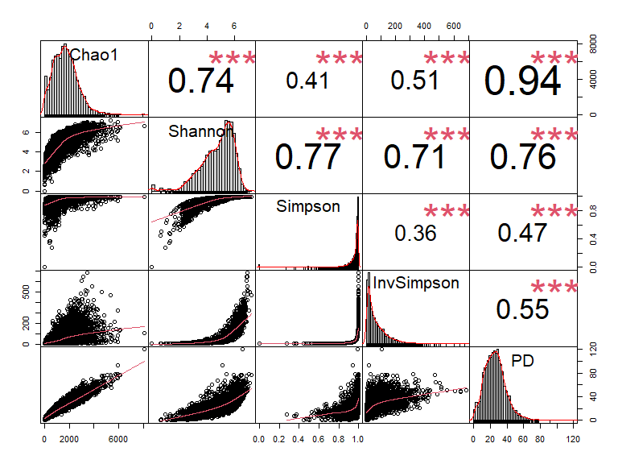

```r
chart.Correlation(merg_alpha[,-c(1,2,4)], histogram=TRUE, pch=19)
```

```r
# prepare matrix

merg_alpha_corr_mat <- merg_alpha %>%
  dplyr::select(-body_site, -se.chao1, -SampleID)  %>%
  as.matrix()

rownames(merg_alpha_corr_mat) <- merg_alpha$SampleID


# use Hmisc package to implement correlation analysis
corr_alpha <- rcorr(merg_alpha_corr_mat, type = "spearman")

corr_alpha
```

```
##            Chao1 Shannon Simpson InvSimpson   PD
## Chao1       1.00    0.80    0.64       0.64 0.94
## Shannon     0.80    1.00    0.95       0.95 0.81
## Simpson     0.64    0.95    1.00       1.00 0.65
## InvSimpson  0.64    0.95    1.00       1.00 0.65
## PD          0.94    0.81    0.65       0.65 1.00
##
## n
##            Chao1 Shannon Simpson InvSimpson   PD
## Chao1       4743    4743    4743       4743 4707
## Shannon     4743    4743    4743       4743 4707
## Simpson     4743    4743    4743       4743 4707
## InvSimpson  4743    4743    4743       4743 4707
## PD          4707    4707    4707       4707 4707
##
## P
##            Chao1 Shannon Simpson InvSimpson PD
## Chao1             0       0       0          0
## Shannon     0             0       0          0
## Simpson     0     0               0          0
## InvSimpson  0     0       0                  0
## PD          0     0       0       0
```

```r
# ++++++++++++++++++++++++++++
# flattenCorrMatrix
# ++++++++++++++++++++++++++++
# cormat : matrix of the correlation coefficients
# pmat : matrix of the correlation p-values
flattenCorrMatrix <- function(cormat, pmat) {
  ut <- upper.tri(cormat)
  data.frame(
    row = rownames(cormat)[row(cormat)[ut]],
    column = rownames(cormat)[col(cormat)[ut]],
    cor  =(cormat)[ut],
    p = pmat[ut]
    )
}
```

```r
flattenCorrMatrix(corr_alpha$r, corr_alpha$P)
```

| row | column | cor | p |
| --- | --- | --- | --- |
| Chao1 | Shannon | 0.8045661 | 0 |
| Chao1 | Simpson | 0.6383711 | 0 |
| Shannon | Simpson | 0.9526515 | 0 |
| Chao1 | InvSimpson | 0.6383711 | 0 |
| Shannon | InvSimpson | 0.9526515 | 0 |
| Simpson | InvSimpson | 1.0000000 | 0 |
| Chao1 | PD | 0.9423121 | 0 |
| Shannon | PD | 0.8057504 | 0 |
| Simpson | PD | 0.6528510 | 0 |
| InvSimpson | PD | 0.6528510 | 0 |

Plot the Spearman-based correlation matrix using `corrplot` function in `corrplot` package following the online [guide](http://www.sthda.com/english/wiki/correlation-matrix-a-quick-start-guide-to-analyze-format-and-visualize-a-correlation-matrix-using-r-software).

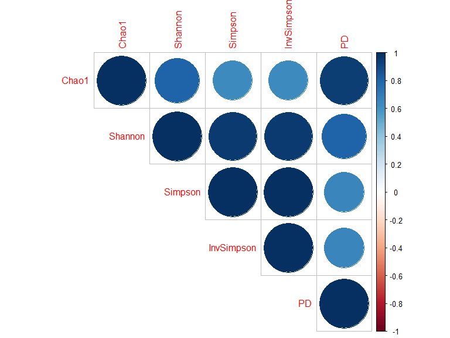

```r
# Insignificant correlations are leaved blank

corrplot(corr_alpha$r,
         type="upper",
         order="original")
```

```r
         # p.mat = p_corr,
         # sig.level = 0.05,
         # insig = "blank")
```

### 0.4.7 Multivariate regression between the alpha diversity and environmental variables

The covariables present in the metadata includes `visitno`, `sex`, `RUNCENTER`, and `body_site`.

```r
dplyr::glimpse(sample_data2) # structure of the metadata
```

```
## Rows: 4,743
## Columns: 10
## $ X.SampleID     <int> 700114607, 700114424, 700114712, 700114713, 700114554, …
## $ RSID           <int> 763901136, 764042746, 764831721, 764831721, 875002022, …
## $ visitno        <int> 2, 2, 2, 2, 1, 2, 2, 2, 2, 2, 2, 2, 2, 2, 1, 2, 2, 1, 2…
## $ sex            <chr> "female", "female", "male", "male", "female", "female",…
## $ RUNCENTER      <chr> "WUGC", "WUGC", "WUGC", "WUGC", "WUGC", "WUGC", "WUGC",…
## $ HMPbodysubsite <chr> "Left_Retroauricular_crease", "Left_Retroauricular_crea…
## $ Mislabeled     <lgl> FALSE, FALSE, FALSE, FALSE, FALSE, FALSE, FALSE, FALSE,…
## $ Contaminated   <lgl> FALSE, FALSE, FALSE, FALSE, FALSE, FALSE, FALSE, FALSE,…
## $ Description    <chr> "HMP_Human_metagenome_sample_700114607_from_subject_763…
## $ body_site      <chr> "skin", "skin", "oral_cavity", "oral_cavity", "nasal_ca…
```

```r
table(sample_data2$RUNCENTER)  # run center distribution
```

```
##
##       BCM    BCM,BI  BCM,JCVI  BCM,WUGC        BI    BI,BCM      JCVI   JCVI,BI
##       696       103        40        90      1078        13      1009        75
## JCVI,WUGC      WUGC  WUGC,BCM WUGC,JCVI
##        93      1539         6         1
```

Check whether zero values/ missing values are present in covariables.

Treat zeroness with proper method, with referring to the `Chap 10.1.4.3` “How to deal zeros in compositional data analysis” in the Book, Statistical Analysis of Microbiome Data with R. Try to use `zComposition` package to treat zero values in categorical variables.

```r
# subset covariables of interest
sample_data2_cov <- sample_data2  %>%
  dplyr::select(SampleID = X.SampleID, visitno, sex, RUNCENTER, body_site)

# apply zPatterns function to find and display missing and zero values
# zPatterns(sample_data2_cov,
#           label = NA,
#           plot= TRUE)
```

Null hypothesis is the row and the column variables of the contingency table are independent; alternative hypothesis is row and column variables are dependent. Note that the assumption of chi-squared test is that the expected frequency of any cell is at least 5.

Refer to [sthda.com](http://www.sthda.com/english/wiki/chi-square-test-of-independence-in-r) for R coding to implement chi-squared test.

```r
# convert covariables of interest to categorical

table(sample_data2_cov$visitno)  # contingency table for visit no - three levels 1, 2 and 3
```

```
##
##    1    2    3
## 2822 1897   24
```

```r
table(sample_data2_cov$sex) # two levels female and male
```

```
##
## female   male
##   2188   2555
```

```r
table(sample_data2_cov$RUNCENTER)  # four levels - BCM, BI, JCVI, and WUGC
```

```
##
##       BCM    BCM,BI  BCM,JCVI  BCM,WUGC        BI    BI,BCM      JCVI   JCVI,BI
##       696       103        40        90      1078        13      1009        75
## JCVI,WUGC      WUGC  WUGC,BCM WUGC,JCVI
##        93      1539         6         1
```

```r
# accumulate sub-groups into a single major group
sample_data2_cov <- sample_data2_cov %>%
  mutate(runcenter = case_when(RUNCENTER %in% c("BCM", "BCM,BI", "BCM,JCVI", "BCM,WUGC")~"BCM",
                               RUNCENTER %in% c("BI", "BI,BCM")~"BI",
                               RUNCENTER %in% c("JCVI", "JCVI,BI", "JCBI,WUGC")~"JCVI",
                               RUNCENTER %in% c("WUGC", "WUGC,BCM","WUGC,JCVI")~"WUGC"))

table(sample_data2_cov$body_site) # five levels - gastrointestinal tract, nasal cavity, oral cavity, skin and urogenital tract
```

```
##
## gastrointestinal_tract           nasal_cavtiy            oral_cavity
##                    319                    269                   2774
##                   skin       urogenital_tract
##                    990                    391
```

```r
# convert to factor variables
sample_data2_cov2 <- sample_data2_cov %>%
  dplyr::select(-SampleID) %>%
  dplyr::select(-RUNCENTER) %>%
  dplyr::mutate(visitno = factor(visitno)) %>%
  mutate(sex = factor(sex, levels = c("female", "male"))) %>%
  mutate(body_site = factor(body_site)) %>%
  mutate(runcenter = factor(runcenter))
```

Apply `lares` package to compute and plot correlations between categorical variables. View this [web site](https://statsandr.com/blog/correlogram-in-r-how-to-highlight-the-most-correlated-variables-in-a-dataset/) for R codes and plotting examples.

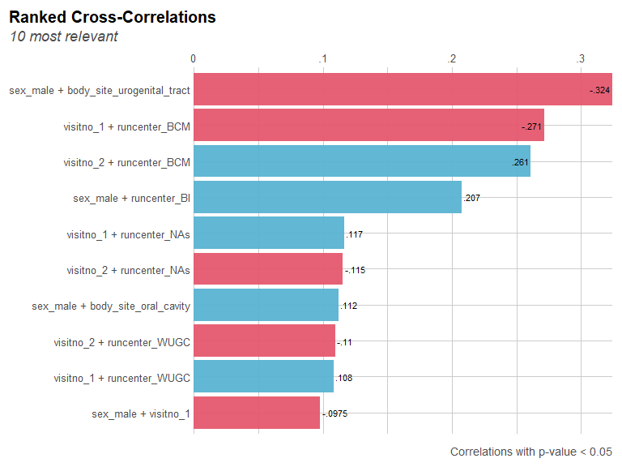

```r
lares::corr_cross(sample_data2_cov2,  # name of dataset
                  max_pvalue = 0.05,  # display only significant correlation (at 5% level)
                  top = 10) # display top 10 couples of variables (by correlation coefficient)
```

The sex (`sex`) and urogenital tract (`body_site`) are correlated with low-to-medium strength while other pair-wise correlations are low-to-weak.

Build multiple linear regression between alpha diversities and four covariables.

```r
# alpha diversities data frame
head(merg_alpha_corr_mat)
```

```
##              Chao1   Shannon   Simpson InvSimpson       PD
## 700114607    3.000 0.6931472 0.5000000    2.00000  0.00000
## 700114424   70.000 2.5350252 0.9062500   10.66667  0.88531
## 700114712 3072.282 5.6003867 0.9791189   47.89016 32.05334
## 700114713 2763.057 6.0508867 0.9913725  115.90813 36.85539
## 700114554 1411.991 4.9824609 0.9790836   47.80928 22.03953
## 700114606 2527.729 6.4212842 0.9960446  252.82161 47.73164
```

```r
# merge covariables and the alpha diversities
# alpha diversity data frame
merg_alpha_corr_df <- merg_alpha_corr_mat %>%
  as.data.frame() %>%
  rownames_to_column("SampleID")

dim(merg_alpha_corr_df)  # 4743 observations
```

```
## [1] 4743    6
```

Check missing/zero values in dependent variables using `zCompositions` package.

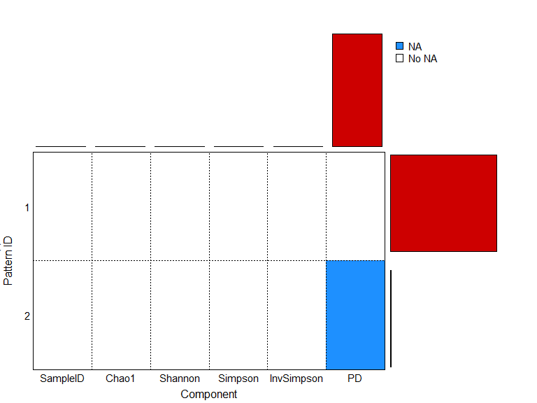

```
## Patterns ('+' means NA, '-' means No NA)
##
##  Patt.ID SampleID Chao1 Shannon Simpson InvSimpson PD No.Unobs Patt.Perc
##        1        -     -       -       -          -  -        0     99.24
##        2        -     -       -       -          -  +        1      0.76
##
## Percentage cells by component
##   SampleID      Chao1    Shannon    Simpson InvSimpson         PD
##       0.00       0.00       0.00       0.00       0.00       0.76
##
## Overall percentage cells: 0.13%
```

```r
zPatterns(merg_alpha_corr_df,
          label = NA,
          plot= TRUE)
```

Missing values are present in one dependent variable, `PD`.

Check visually whether dependent variables normally distribute.

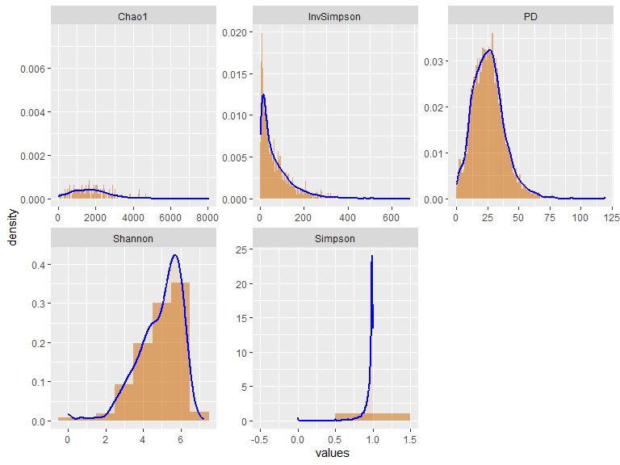

```r
merg_alpha_corr_df %>%
  gather(key = "alpha_metrics", value = "values", -SampleID) %>%
  ggplot(aes(x = values, y =..density..))+
  geom_histogram(stat = "bin", binwidth = 1, alpha = 0.5) +
  facet_wrap(vars(alpha_metrics),
             scales = "free") +
  geom_density(color = "blue",
               linewidth = 1,
               alpha = 0.1)
```

```r
# covariables data frame
sample_data2_cov2_df <- sample_data2_cov2 %>%
  rownames_to_column("SampleID")

dim(sample_data2_cov2_df)  # 4743 observations
```

```
## [1] 4743    5
```

```r
# join two data frames by sample ID
alpha_cov_df <- merg_alpha_corr_df %>%
  full_join(sample_data2_cov2_df, by= "SampleID")

dim(alpha_cov_df)  # 4743 observations
```

```
## [1] 4743   10
```

```r
names(alpha_cov_df)
```

```
##  [1] "SampleID"   "Chao1"      "Shannon"    "Simpson"    "InvSimpson"
##  [6] "PD"         "visitno"    "sex"        "body_site"  "runcenter"
```

Dependent variables: `Chao1` `Shannon` `Simpson` `InvSimpson` `PD`

Independent variables: `visitno` `sex` `body_site` `runcenter`

```r
# Chao1 model
mod_chao1 <- lm(Chao1 ~  body_site + visitno + sex + runcenter,
   data = alpha_cov_df,
   na.action =  na.omit # omit NA
   )

# summary(mod_chao1)  # coefficients and significance of the resulting model



#  Shannon mod
mod_shann <- lm(Shannon ~  body_site + visitno + sex + runcenter,
   data = alpha_cov_df,
   na.action =  na.omit # omit NA
   )


# Simpson mod
mod_simpson <- lm(Simpson ~  body_site + visitno + sex + runcenter,
   data = alpha_cov_df,
   na.action =  na.omit # omit NA
   )


# Inverse Simpson mod
mod_invsimpson <- lm(InvSimpson ~  body_site + visitno + sex + runcenter,
   data = alpha_cov_df,
   na.action =  na.omit # omit NA
   )


# PD mod
mod_pd <- lm(PD ~  body_site + visitno + sex + runcenter,
   data = alpha_cov_df,
   na.action =  na.omit # omit NA
   )
```

The model coefficients tell us that, - Body sites are associated with alpha diversity, Chao1. Oral cavity has highest diversity compared to other niches. - Visit number (sampling time) is linked to alpha diversity, Chao1.  
- Run centers are associated with alpha diversity, Chao1, suggesting that technical variations exist in the data set. - Sex is linked to alpha diversity, Chao1, male has higher alpha diversity than female does.

Overall, four covariables collectively explain 47.35% variation of average alpha diversity, Chao1.

#### 0.4.7.1 Visualize and tabulate model output

The post in the blog [Stats and R](https://statsandr.com/blog/multiple-linear-regression-made-simple/#coefficient-of-determination-r2) provides a few R packages to visualize or tabulate linear models, including,

- `ggstatsplot`
- `ggstance`
- `parameters` (tabulate)
- `gt` (tabulate)
- `equationmatic` (extract model’s equation)
- `report` (automatic reporting)

In the report, I use `ggstatsplot` to visualize while use `gt` to tabulate the model output for illustration purpose.

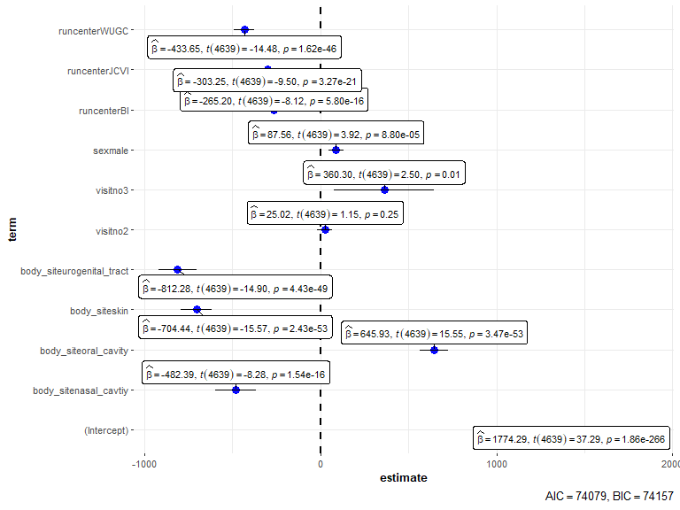

```r
# forest plot to show model output in detailed
ggstatsplot::ggcoefstats(mod_chao1)
```

In this plot:

- when the solid line does not cross the vertical dashed line, the coefficient is different from 0 at the 5% significance level
- a point to the right or to the left of the vertical dashed line indicates positive or negative associations between two variables
- the more extreme the point, the stronger the relationship

Next, tabulate the model output in a HTML-friendly manner using the packages `gt` and `parameters`

```r
print_html(model_parameters(mod_chao1, summary = TRUE))
```

| Parameter | Coefficient | SE | 95% CI | t(4639) | p |
| --- | --- | --- | --- | --- | --- |
| (Intercept) | 1774.29 | 47.58 | (1681.02, 1867.57) | 37.29 | < .001 |
| body site (nasal_cavtiy) | -482.39 | 58.23 | (-596.55, -368.23) | -8.28 | < .001 |
| body site (oral_cavity) | 645.93 | 41.54 | (564.49, 727.37) | 15.55 | < .001 |
| body site (skin) | -704.44 | 45.23 | (-793.12, -615.76) | -15.57 | < .001 |
| body site (urogenital_tract) | -812.28 | 54.52 | (-919.16, -705.41) | -14.90 | < .001 |
| visitno (2) | 25.02 | 21.73 | (-17.57, 67.61) | 1.15 | 0.250 |
| visitno (3) | 360.30 | 143.98 | (78.03, 642.57) | 2.50 | 0.012 |
| sex (male) | 87.56 | 22.31 | (43.82, 131.30) | 3.92 | < .001 |
| runcenter (BI) | -265.20 | 32.65 | (-329.20, -201.19) | -8.12 | < .001 |
| runcenter (JCVI) | -303.25 | 31.92 | (-365.83, -240.67) | -9.50 | < .001 |
| runcenter (WUGC) | -433.65 | 29.95 | (-492.36, -374.94) | -14.48 | < .001 |

Model: Chao1 ~ body_site + visitno + sex + runcenter (4650 Observations) Residual standard deviation: 695.887 (df = 4639) R2: 0.474; adjusted R2: 0.472

#### 0.4.7.2 Predict Chao 1 from four variables

```r
names(alpha_cov_df)
```

```
##  [1] "SampleID"   "Chao1"      "Shannon"    "Simpson"    "InvSimpson"
##  [6] "PD"         "visitno"    "sex"        "body_site"  "runcenter"
```

```r
# create a new data
new_df <- alpha_cov_df[1:3,7:10]


# predict new individuals with 95% prediction interval
predict(mod_chao1,
        new = new_df,
        interval = "prediction",
        level = .95)
```

```
##         fit       lwr      upr
## 1  661.2216 -704.5831 2027.026
## 2  661.2216 -704.5831 2027.026
## 3 2099.1557  733.9361 3464.375
```

### 0.4.8 Diagnose the models

Check up whether regression assumption hold true. The website [sthda](http://www.sthda.com/english/articles/39-regression-model-diagnostics/161-linear-regression-assumptions-and-diagnostics-in-r-essentials/#regression-assumptions) provides detailed instructions on diagnosing models.

Regression assumptions: - linearity of the data - normality of residuals - homogeneity of residuals variance - independence of residuals error terms

All these assumptions and potential problems can be checked by producing some diagnostic plots visualizing the residual errors.

```r
mod_chao1_diag_metrics <- broom::augment(mod_chao1)

head(mod_chao1_diag_metrics)
```

| .rownames | Chao1 | body_site | visitno | sex | runcenter | .fitted | .resid | .hat | .sigma | .cooksd | .std.resid |
| --- | --- | --- | --- | --- | --- | --- | --- | --- | --- | --- | --- |
| 1 | 3.000 | skin | 2 | female | WUGC | 661.2216 | -658.2216 | 0.002251659 | 695.8949 | 1.839647e-04 | -0.9469408 |
| 2 | 70.000 | skin | 2 | female | WUGC | 661.2216 | -591.2216 | 0.002251659 | 695.9079 | 1.484195e-04 | -0.8505522 |
| 3 | 3072.282 | oral_cavity | 2 | male | WUGC | 2099.1557 | 973.1263 | 0.001393095 | 695.8152 | 2.483474e-04 | 1.3993719 |
| 4 | 2763.057 | oral_cavity | 2 | male | WUGC | 2099.1557 | 663.9009 | 0.001393095 | 695.8938 | 1.155920e-04 | 0.9547006 |
| 5 | 1411.991 | nasal_cavtiy | 1 | female | WUGC | 858.2566 | 553.7340 | 0.004674671 | 695.9144 | 2.716146e-04 | 0.7975903 |
| 6 | 2527.729 | oral_cavity | 2 | female | WUGC | 2011.5962 | 516.1330 | 0.001646160 | 695.9208 | 8.259542e-05 | 0.7423019 |

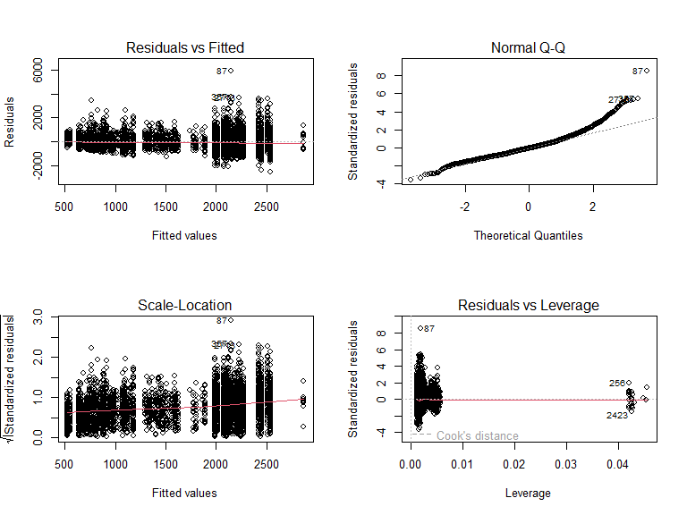

```r
# diagnose plots for chao1 model
par(mfrow = c(2,2))

plot(mod_chao1)
```

Look more closely at the Cook’s distance to identify any influencer points.

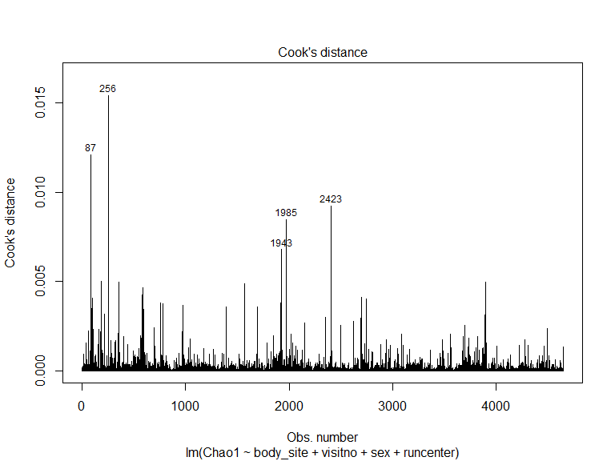

```r
plot(mod_chao1, 4,
     id.n=5) # lable top most extreme values
```

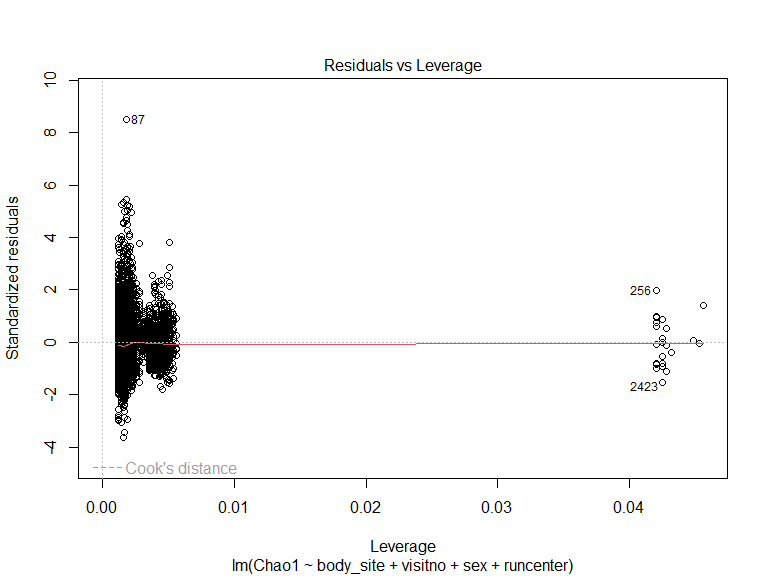

```r
plot(mod_chao1, 5)
```

```r
# look further the top extreme values
mod_chao1_diag_metrics %>%
  top_n(3, wt= .cooksd)
```

| .rownames | Chao1 | body_site | visitno | sex | runcenter | .fitted | .resid | .hat | .sigma | .cooksd | .std.resid |
| --- | --- | --- | --- | --- | --- | --- | --- | --- | --- | --- | --- |
| 87 | 8069.047 | oral_cavity | 2 | female | JCVI | 2142.000 | 5927.047 | 0.001824586 | 690.4890 | 0.012076946 | 8.525034 |
| 256 | 4206.671 | oral_cavity | 3 | male | BCM | 2868.090 | 1338.582 | 0.042034018 | 695.6723 | 0.015407072 | 1.965310 |
| 2423 | 1404.310 | oral_cavity | 3 | male | WUGC | 2434.438 | -1030.128 | 0.042517038 | 695.7904 | 0.009238749 | -1.512819 |

“A Framework for Human Microbiome Research.” 2012. *Nature* 486 (7402): 215–21. https://doi.org/10.1038/nature11209.